# New and modified functionality in xcms

Johannes Rainer

#### Package: xcms

# 1 New functionality in `xcms`

This document describes new functionality and changes to existing functionality in the `xcms` package introduced during the update to version *3*.

```r
library(xcms)
library(RColorBrewer)
register(SerialParam())
```

## 1.1 Modernized user interface

The modernization of the user interface comprises new classes for data representation and new data analysis methods. In addition, the core logic for the data processing has been extracted from the old methods and put into a set of R functions, the so called core API functions (or `do_` functions). These functions take standard R data structures as input and return standard R data types as result and can hence be easily included in other R packages.

The new user interface aims at simplifying and streamlining the `xcms` workflow while guaranteeing data integrity and performance also for large scale metabolomics experiments. Importantly, a simplified access to the original raw data should be provided throughout the whole metabolomics data analysis workflow.

The new interface re-uses objects from the `MSnbase` Bioconductor package, such as the `OnDiskMSnExp` object. This object is specifically designed for large scale MS experiments as it initially reads just the scan header information from the mzML while the mz-intensity value pairs from all or from selected spectra of a file are read on demand hence minimizing the memory demand. Also, in contrast to the old `xcmsRaw` object, the `OnDiskMSnExp` contains information from all files of an experiment. In addition, all data normalization and adjustment methods implemented in the `MSnbase` package can be directly applied to the MS data without the need to re-implement such methods in `xcms`. Results from `xcms` preprocessings, such as chromatographic peak detection or correspondence are stored into the new `XCMSnExp` object. This object extends the `OnDiskMSnExp` object and inherits thus all of its methods including raw data access.

Class and method/function names follow also a new naming convention trying tp avoid the partially confusing nomenclature of the original `xcms` methods (such as the `group` method to perform the correspondence of peaks across samples). To distinguish them from mass peaks, the peaks identified by the peak detection in an LS/GC-MS experiment are referred to as *chromatographic peaks*. The respective method to identify such peaks is hence called `findChromPeaks` and the identified peaks can be accessed using the `XCMSnExp` `chromPeaks` method. The results from an correspondence analysis which aims to match and group chromatographic peaks within and between samples are called *features*. The definition of such mz-rt features (i.e. the result from the `groupChromPeaks` method) can be accessed *via* the `featureDefinitions` method of the `XCMSnExp` class. Finally, alignment (retention time correction) can be performed using the `adjustRtime` method.

The settings for any of the new analysis methods are bundled in *parameter* classes, one class for each method. This encapsulation of the parameters to a function into a parameter class (such as `CentWaveParam`) avoids busy function calls (with many single parameters) and enables saving, reloading and reusing the settings. In addition, the parameter classes are added, along with other information to the process history of an `XCMSnExp` object thus providing a detailed documentation of each processing step of an analysis, with the possibility to recall all settings of the performed analyses at any stage. In addition, validation of the parameters can be performed within the parameter object and hence is no longer required in the analysis function.

The example below illustrates the new user interface. First we load the raw data files from the `faahKO` package using the `readMSData2` from the `MSnbase` package.

```r
## Reading the raw data using the MSnbase package
library(xcms)
## Load 6 of the CDF files from the faahKO
cdf_files <- dir(system.file("cdf", package = "faahKO"), recursive = TRUE,
         full.names = TRUE)[c(1:3, 7:9)]

## Define the sample grouping.
s_groups <- rep("KO", length(cdf_files))
s_groups[grep(cdf_files, pattern = "WT")] <- "WT"
## Define a data.frame that will be used as phenodata
pheno <- data.frame(sample_name = sub(basename(cdf_files), pattern = ".CDF",
                      replacement = "", fixed = TRUE),
            sample_group = s_groups, stringsAsFactors = FALSE)

## Read the data.
raw_data <- readMSData2(cdf_files, pdata = new("NAnnotatedDataFrame", pheno))
```

We next plot the total ion chromatogram (TIC) for all files within the experiment. Note that we are iteratively sub-setting the full data per file using the `filterFile` method, which, for `OnDiskMSnExp` objects, is an efficient way to subset the data while ensuring that all data, including metadata, stays consistent.

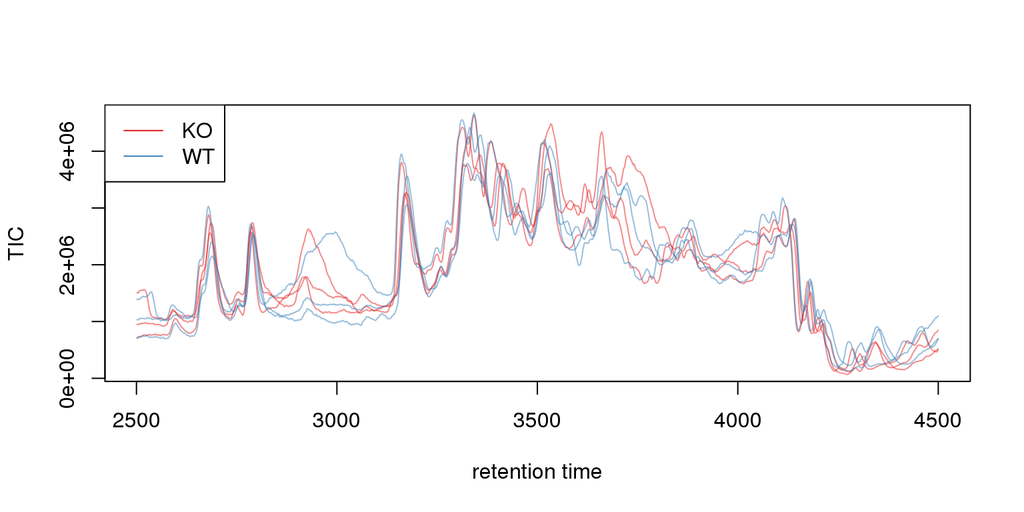

```r
library(RColorBrewer)
sample_colors <- brewer.pal(3, "Set1")[1:2]
names(sample_colors) <- c("KO", "WT")
## Subset the full raw data by file and plot the data.
tmp <- filterFile(raw_data, file = 1)
plot(x = rtime(tmp), y = tic(tmp), xlab = "retention time", ylab = "TIC",
     col = paste0(sample_colors[pData(tmp)$sample_group], 80), type = "l")
for (i in 2:length(fileNames(raw_data))) {
    tmp <- filterFile(raw_data, file = i)
    points(rtime(tmp), tic(tmp), type = "l",
       col = paste0(sample_colors[pData(tmp)$sample_group], 80))
}
legend("topleft", col = sample_colors, legend = names(sample_colors), lty = 1)
```

Alternatively we can use the `extractChromatograms` method that extracts chromatograms from the object. In the example below we extract the *base peak chromatogram* (BPC) by setting `aggregationFun` to `"max"` and not specifying an `rt` or `mz` range to extract only a data subset. In contrast to the `tic` and `bpi` methods, this function reads the data from the raw files.

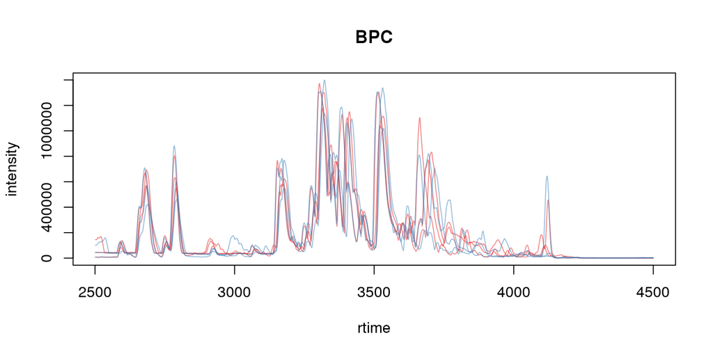

```r
## Get the base peak chromatograms. This reads data from the files.
bpis <- extractChromatograms(raw_data, aggregationFun = "max")
plot(3, 3, pch = NA, xlim = range(unlist(lapply(bpis, rtime))),
     ylim = range(unlist(lapply(bpis, intensity))), main = "BPC",
     xlab = "rtime", ylab = "intensity")
for (i in 1:length(bpis)) {
    points(rtime(bpis[[i]]), intensity(bpis[[i]]), type = "l",
       col = paste0(sample_colors[pData(raw_data)$sample_group[i]], 80))
}
```

Note that we could restrict the analysis to a certain retention time range by sub-setting `raw_data` with the `filterRt` method.

In addition we can plot the distribution of the total ion counts per file. In contrast to sub-setting the object we split the numeric vector returned by the `tic` by file using the `fromFile` method that provides the mapping of the experiment’s spectra to the originating files.

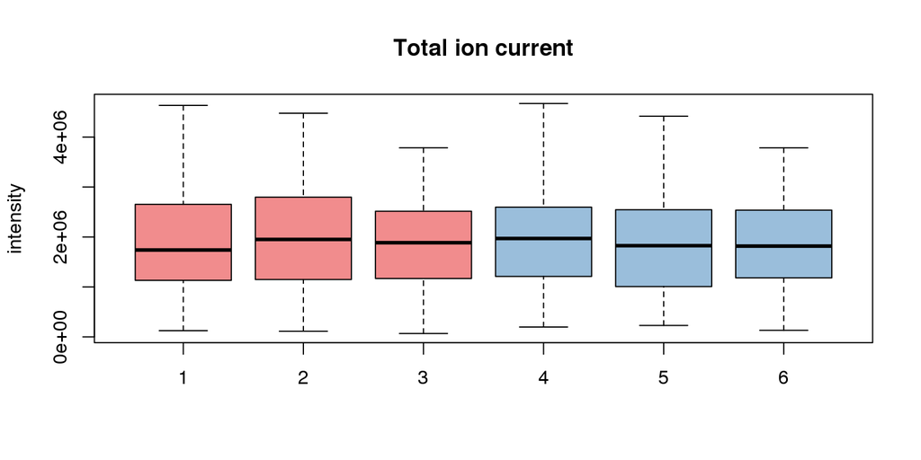

```r
## Get the total ion current by file
tc <- split(tic(raw_data), f = fromFile(raw_data))
boxplot(tc, col = paste0(sample_colors[pData(raw_data)$sample_group], 80),
    ylab = "intensity", main = "Total ion current")
```

The `tic` (and for mzML files) the `bpi` methods are very fast, even for large data sets, as these information are stored in the header of the raw files avoiding the need to read the raw data from each file. Also, we could subset the whole object using the filter functions `filterFile`, `filterRt` or `filterMz` to e.g. remove problematic samples or restrict the retention time range in which we want to perform the chromatographic peak detection.

Next we perform the chromatographic peak detection using the *centWave* algorithm [@Tautenhahn:2008fx]. In the example below we use most of the standard parameters, but the settings should be adjusted to each experiment individually based on e.g. the expected width of the chromatographic peaks etc.

```r
## Defining the settings for the centWave peak detection.
cwp <- CentWaveParam(snthresh = 20, noise = 1000)
xod <- findChromPeaks(raw_data, param = cwp)
```

```
## Detecting mass traces at 25 ppm ...
```

```
## OK
```

```
## Detecting chromatographic peaks in 17808 regions of interest ...
```

```
##  OK: 540 found.
```

```
## Detecting mass traces at 25 ppm ...
```

```
## OK
```

```
## Detecting chromatographic peaks in 18651 regions of interest ...
```

```
##  OK: 649 found.
```

```
## Detecting mass traces at 25 ppm ...
```

```
## OK
```

```
## Detecting chromatographic peaks in 16040 regions of interest ...
```

```
##  OK: 445 found.
```

```
## Detecting mass traces at 25 ppm ...
```

```
## OK
```

```
## Detecting chromatographic peaks in 18718 regions of interest ...
```

```
##  OK: 548 found.
```

```
## Detecting mass traces at 25 ppm ...
```

```
## OK
```

```
## Detecting chromatographic peaks in 14431 regions of interest ...
```

```
##  OK: 444 found.
```

```
## Detecting mass traces at 25 ppm ...
```

```
## OK
```

```
## Detecting chromatographic peaks in 15209 regions of interest ...
```

```
##  OK: 472 found.
```

The identified peaks can be accessed with the `chromPeaks` parameter which returns a `matrix`, each line representing an identified peak. Column `"sample"` specifies in which *sample* (i.e. file) of the experiment the peak was detected. Below we plot the signal distribution of the identified peaks per sample.

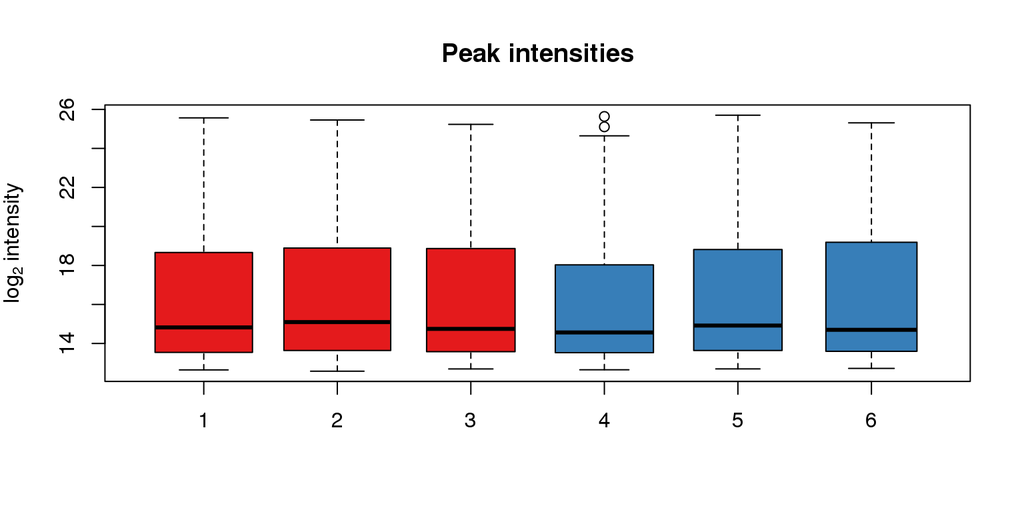

```r
ints <- split(chromPeaks(xod)[, "into"], f = chromPeaks(xod)[, "sample"])
ints <- lapply(ints, log2)
boxplot(ints, varwidth = TRUE, col = sample_colors[pData(xod)$sample_group],
    ylab = expression(log[2]~intensity), main = "Peak intensities")
```

After peak detection it might be advisable to evaluate whether the peak detection identified e.g. compounds known to be present in the sample. Facilitating access to the raw data has thus been one of the major aims for the updated user interface.

Next we extract the chromatogram for the rt-mz region corresponding to one detected chromatographic peak increasing the region in rt dimension by +/- 60 seconds. In addition we extract also all chromatographic peaks in that region by passing the same `mz` and `rt` parameters to the `chromPeaks` method.

```r
rtr <- chromPeaks(xod)[68, c("rtmin", "rtmax")]
## Increase the range:
rtr[1] <- rtr[1] - 60
rtr[2] <- rtr[2] + 60
mzr <- chromPeaks(xod)[68, c("mzmin", "mzmax")]

chrs <- extractChromatograms(xod, rt = rtr, mz = mzr)

## In addition we get all peaks detected in the same region
pks <- chromPeaks(xod, rt = rtr, mz = mzr)
```

Next we plot the extracted chromatogram for the data and highlight in addition the identified peaks.

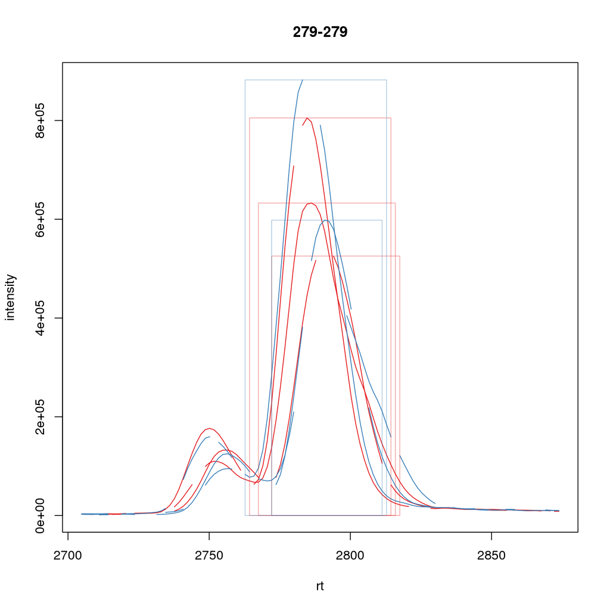

Figure 1: Extracted ion chromatogram for one of the identified peaks. Each line represents the signal measured in one sample. The rectangles indicate the margins of the identified chromatographic peak in the respective sample.

```r
## Define the limits on x- and y-dimension
xl <- range(lapply(chrs, rtime), na.rm = TRUE)
yl <- range(lapply(chrs, intensity), na.rm = TRUE)
plot(3, 3, pch = NA, main = paste(format(mzr, digits = 6), collapse = "-"),
     xlab = "rt", ylab = "intensity", xlim = xl, ylim = yl)
## Plot the chromatogram per sample
for (i in 1:length(chrs)) {
    points(rtime(chrs[[i]]), intensity(chrs[[i]]), type = "l",
       col = sample_colors[pData(xod)$sample_group[i]])
}
## Highlight the identified chromatographic peaks.
for (i in 1:nrow(pks)) {
    rect(xleft = pks[i, "rtmin"], xright = pks[i, "rtmax"], ybottom = 0,
     ytop = pks[i, "maxo"],
     border = paste0(sample_colors[pData(xod)$sample_group][pks[i, "sample"]], 60))
}
```

Note that the `extractChromatograms` does return an `NA` value if in a certain scan (i.e. for a specific retention time) no signal was measured in the respective mz range. This is reflected by the lines not being drawn as continuous lines in the plot above.

Next we align the samples using the *obiwarp* method [@Prince:2006jj]. This method does not require, in contrast to other alignment/retention time correction methods, any identified peaks and could thus also be applied to an `OnDiskMSnExp` object. Note that all retention time adjustment methods do also adjust the retention times reported for the individual peaks in `chromPeaks`.

```r
## Doing the obiwarp alignment using the default settings.
xod <- adjustRtime(xod, param = ObiwarpParam())
```

Note that any pre-processing results can be removed at any time using a *drop* method, such as `dropChromPeaks`, `dropFeatureDefinitions` or `dropAdjustedRtime`.

To evaluate the impact of the alignment we can plot again the BPC of each sample. In addition we plot the differences of the adjusted to the raw retention times per sample using the `plotAdjustedRtime` function.

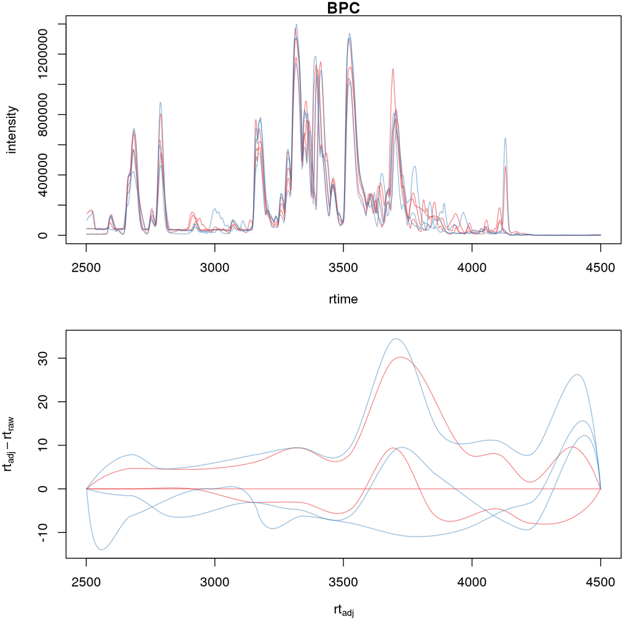

```r
## Get the base peak chromatograms. This reads data from the files.
bpis <- extractChromatograms(xod, aggregationFun = "max")

par(mfrow = c(2, 1), mar = c(4.5, 4.2, 1, 0.5))
plot(3, 3, pch = NA, xlim = range(unlist(lapply(bpis, rtime))),
     ylim = range(unlist(lapply(bpis, intensity))), main = "BPC",
     xlab = "rtime", ylab = "intensity")
for (i in 1:length(bpis)) {
    points(rtime(bpis[[i]]), intensity(bpis[[i]]), type = "l",
       col = paste0(sample_colors[pData(xod)$sample_group[i]], 80))
}
## Plot also the difference of adjusted to raw retention time.
plotAdjustedRtime(xod, col = paste0(sample_colors[pData(xod)$sample_group], 80))
```

Too large differences between adjusted and raw retention times could indicate poorly performing samples or alignment.

The distribution of retention time differences could also be used for quality assessment.

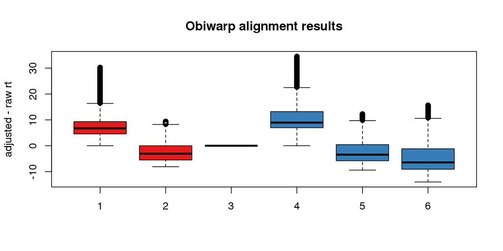

```r
## Calculate the difference between the adjusted and the raw retention times.
diffRt <- rtime(xod) - rtime(xod, adjusted = FALSE)

## By default, rtime and most other accessor methods return a numeric vector. To
## get the values grouped by sample we have to split this vector by file/sample
diffRt <- split(diffRt, fromFile(xod))

boxplot(diffRt, col = sample_colors[pData(xod)$sample_group],
    main = "Obiwarp alignment results", ylab = "adjusted - raw rt")
```

The 3rd sample was used as *center* sample against which all other samples were aligned to, hence its adjusted retention times are identical to the raw retention times.

We are again plotting the extracted ion chromatogram for the selected peaks from above to evaluate the impact of the alignment.

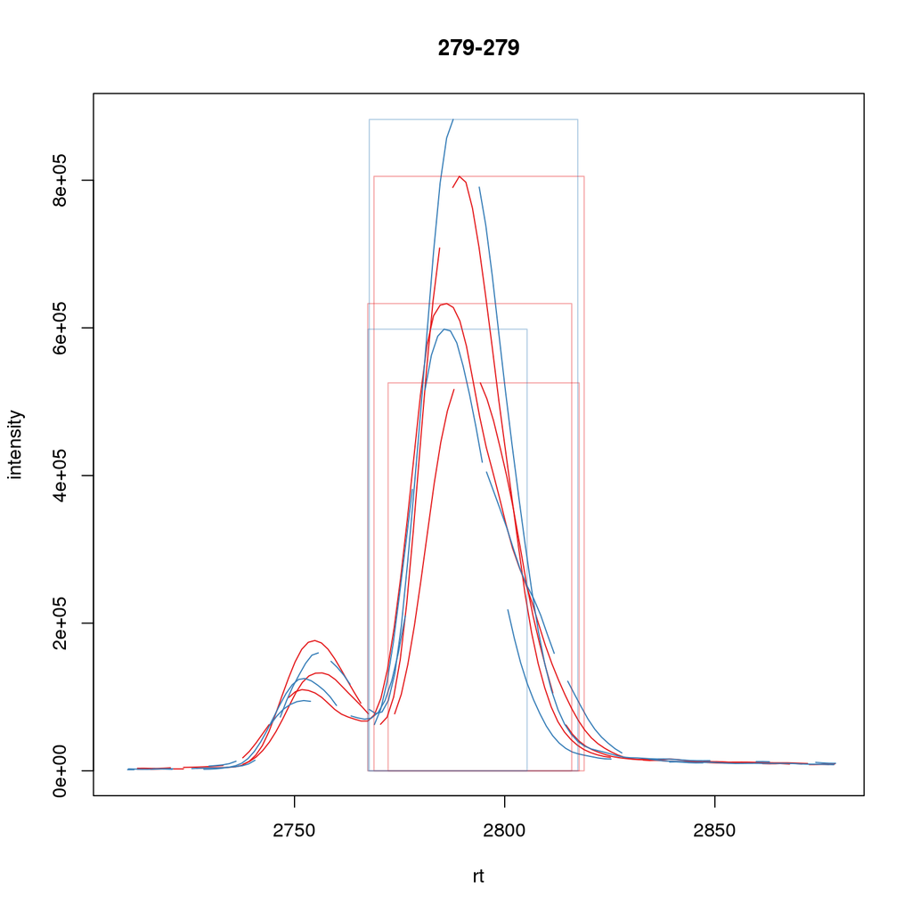

Figure 2: Extracted ion chromatogram for one of the identified peaks after alignment.

After alignment, the peaks are nicely overlapping.

```r
## Define the PeakDensityParam
pdp <- PeakDensityParam(sampleGroups = pData(xod)$sample_group,
            maxFeatures = 300, minFraction = 0.66)
xod <- groupChromPeaks(xod, param = pdp)
```

The definitions of the features can be accessed with the `featureDefinitions`, which lists the mz-rt space specific to a feature. Column `"peakidx"` lists the indices (in the `chromPeaks` matrix) of the individual chromatographic peaks belonging to the feature.

```r
head(featureDefinitions(xod))
```

```
## DataFrame with 6 rows and 10 columns
##           mzmed     mzmin     mzmax     rtmed     rtmin     rtmax
##       <numeric> <numeric> <numeric> <numeric> <numeric> <numeric>
## FT001     205.0     205.0     205.0  2788.485  2785.576  2791.067
## FT002     207.1     207.1     207.1  2716.355  2712.648  2718.939
## FT003     208.9     208.9     208.9  2606.350  2589.015  2667.274
## FT004     220.9     220.9     221.0  3234.088  3233.777  3247.385
## FT005     228.9     228.9     228.9  2659.407  2654.744  2664.070
## FT006     241.2     241.2     241.2  2911.009  2838.057  2955.814
##          npeaks        KO        WT         peakidx
##       <numeric> <numeric> <numeric>          <list>
## FT001         6         3         3 75,635,1252,...
## FT002         3         2         1   598,1224,2232
## FT003         3         1         2   558,1642,2212
## FT004         3         1         2  1344,1887,2829
## FT005         2         2         0          24,574
## FT006         5         1         2 642,659,675,...
```

To extract *values* for the features, the `featureValues` method can be used. This method returns a matrix with rows being the features and column the samples. The `value` parameter allows to specify the value that should be returned. Below we extract the `"into"` signal, i.e. the per-peak integrated intensity for each feature.

```r
## Extract the "into" peak integrated signal.
head(featureValues(xod, value = "into"))
```

```
##         ko15.CDF   ko16.CDF   ko18.CDF   wt15.CDF    wt16.CDF    wt18.CDF
## FT001 1924712.02 1757150.96 1714581.78 2129885.09 1634341.986 1810112.276
## FT002         NA  451863.66  337473.31         NA  360908.934          NA
## FT003         NA   18319.89         NA   24254.37    7860.995          NA
## FT004         NA         NA   13012.98   38930.94          NA    9087.955
## FT005   19707.81   15966.13         NA         NA          NA          NA
## FT006         NA   12387.22         NA         NA   12759.445    9455.730
```

After correspondence there will always be features that do not include peaks from every sample (being it that the peak finding algorithm failed to identify a peak or that no signal was measured in the respective mz-rt area). For such features an `NA` is returned by the `featureValues` method. Here, `xcms` allows to infer values for such missing peaks using the `fillChromPeaks` method. This method integrates in files where a peak was not found the signal from the mz-rt area where it is expected and adds it to the `chromPeaks` matrix. Such *filled-in* peaks have a value of `1` in the `"is_filled"` column of the `chromPeaks` matrix.

```r
## Fill in peaks with default settings. Settings can be adjusted by passing
## a FillChromPeaksParam object to the method.
xod <- fillChromPeaks(xod)

head(featureValues(xod, value = "into"))
```

```
##         ko15.CDF   ko16.CDF    ko18.CDF   wt15.CDF    wt16.CDF    wt18.CDF
## FT001 1924712.02 1757150.96 1714581.776 2129885.09 1634341.986 1810112.276
## FT002  362020.63  451863.66  337473.308  353054.86  360908.934  267456.999
## FT003         NA   18319.89          NA   24254.37    7860.995          NA
## FT004   10434.64         NA   13012.975   38930.94   23296.981    9087.955
## FT005   19707.81   15966.13    6429.364         NA          NA    8981.056
## FT006         NA   12387.22    6494.872         NA   12759.445    9455.730
```

Not for all missing peaks a value could be integrated (because at the respective location no measurements are available). The peak area from which signal is to be extracted can also be increased modifying the settings by passing a `FillChromPeaksParam` object.

Next we inspect the `processHistory` of the analysis. As described earlier, this records all (major) processing steps along with the corresponding parameter classes.

```r
## List the full process history
processHistory(xod)
```

```
## [[1]]
## Object of class "XProcessHistory"
##  type: Peak detection
##  date: Tue Apr 25 17:48:43 2017
##  info:
##  fileIndex: 1,2,3,4,5,6
##  Parameter class: CentWaveParam
##
## [[2]]
## Object of class "XProcessHistory"
##  type: Retention time correction
##  date: Tue Apr 25 17:49:25 2017
##  info:
##  fileIndex: 1,2,3,4,5,6
##  Parameter class: ObiwarpParam
##
## [[3]]
## Object of class "XProcessHistory"
##  type: Peak grouping
##  date: Tue Apr 25 17:49:39 2017
##  info:
##  fileIndex: 1,2,3,4,5,6
##  Parameter class: PeakDensityParam
##
## [[4]]
## Object of class "XProcessHistory"
##  type: Missing peak filling
##  date: Tue Apr 25 17:49:41 2017
##  info:
##  fileIndex: 1,2,3,4,5,6
##  Parameter class: FillChromPeaksParam
```

It is also possible to extract specific processing steps by specifying its type. Available types can be listed with the `processHistoryTypes` function. Below we extract the parameter class for the alignment/retention time adjustment step.

```r
ph <- processHistory(xod, type = "Retention time correction")

## Access the parameter
processParam(ph[[1]])
```

```
## Object of class:  ObiwarpParam
## Parameters:
##  binSize: 1
##  centerSample:
##  response: 1
##  distFun: cor_opt
##  gapInit: 0.3
##  gapExtend: 2.4
##  factorDiag: 2
##  factorGap: 1
##  localAlignment: FALSE
##  initPenalty: 0
```

As described earlier, we can remove specific analysis results at any stage. Below we remove the results from the alignment. Since the correspondence was performed after that processing step its results will be removed too leaving us only with the results from the peak detection step.

```r
## Remove the alignment results
xod <- dropAdjustedRtime(xod)

processHistory(xod)
```

```
## [[1]]
## Object of class "XProcessHistory"
##  type: Peak detection
##  date: Tue Apr 25 17:48:43 2017
##  info:
##  fileIndex: 1,2,3,4,5,6
##  Parameter class: CentWaveParam
```

We can now use a different method to perform the alignment. The *peak groups* alignment method bases the alignment of the samples on chromatographic peaks present in most samples (so called *well behaved* peaks). This means we have to perform first an initial correspondence analysis to group peaks within and across samples.

```r
## Define the parameter for the correspondence
pdparam <- PeakDensityParam(sampleGroups = pData(xod)$sample_group,
                minFraction = 0.7, maxFeatures = 100)
xod <- groupChromPeaks(xod, param = pdparam)
```

Before performing the alignment we can also inspect which peak groups might be selected for alignment based on the provided `PeakGroupsParam` object.

```r
## Create the parameter class for the alignment
pgparam <- PeakGroupsParam(minFraction = 0.9, span = 0.4)

## Extract the matrix with (raw) retention times for the peak groups that would
## be used for alignment.
adjustRtimePeakGroups(xod, param = pgparam)
```

```
##       ko15.CDF ko16.CDF ko18.CDF wt15.CDF wt16.CDF wt18.CDF
## FT006 2712.647 2718.906 2714.213 2712.647 2718.906 2686.043
## FT096 2786.200 2792.459 2787.766 2786.200 2787.764 2795.590
## FT001 2784.635 2790.894 2787.766 2784.635 2790.894 2790.895
## FT048 2797.154 2812.803 2798.720 2797.154 2873.837 2801.849
## FT013 2923.916 2925.480 2923.917 2923.915 2927.045 2928.611
## FT086 3368.362 3313.589 3200.913 3218.127 3235.341 3207.172
## FT079 3341.758 3354.277 3349.584 3340.193 3355.842 3355.843
## FT080 3341.758 3354.277 3349.584 3341.758 3355.842 3355.843
## FT036 3491.994 3502.948 3495.125 3490.429 3502.948 3491.994
## FT026 3493.559 3502.948 3495.125 3490.429 3502.948 3504.514
## FT072 3512.338 3531.117 3523.294 3513.903 3529.552 3531.118
## FT071 3515.468 3529.552 3524.859 3513.903 3529.552 3532.683
## FT025 3618.755 3631.274 3626.581 3614.060 3632.839 3635.970
## FT028 3657.879 3670.398 3664.140 3657.879 3671.963 3671.964
## FT004 3656.314 3671.963 3665.705 3657.879 3671.963 3668.834
## FT078 3662.574 3690.742 3706.393 3661.009 3693.872 3722.042
## FT084 3703.262 3718.912 3712.653 3700.132 3720.476 3712.652
## FT074 3747.081 3767.425 3768.991 3740.821 3767.425 3781.510
## FT073 3748.646 3767.425 3767.426 3740.821 3768.990 3779.945
## FT057 3859.758 3875.407 3870.713 3847.238 3876.972 3875.407
```

If we are not happy with these peak groups (e.g. because we don’t have a peak group for a rather large time span along the retention time axis) we can try different settings. In addition, we could also *manually* select certain peak groups, e.g. for internal controls, and add this matrix with the `peakGroupsMatrix` method to the `PeakGroupsParam` class. Below we just use `pgparam` we defined and perform the alignment. This will use the peak groups matrix from above.

```r
## Perform the alignment using the peak groups method.
xod <- adjustRtime(xod, param = pgparam)
```

We can now also plot the difference between adjusted and raw retention times. If alignment was performed using the *peak groups* method, also these peak groups are highlighted in the plot.

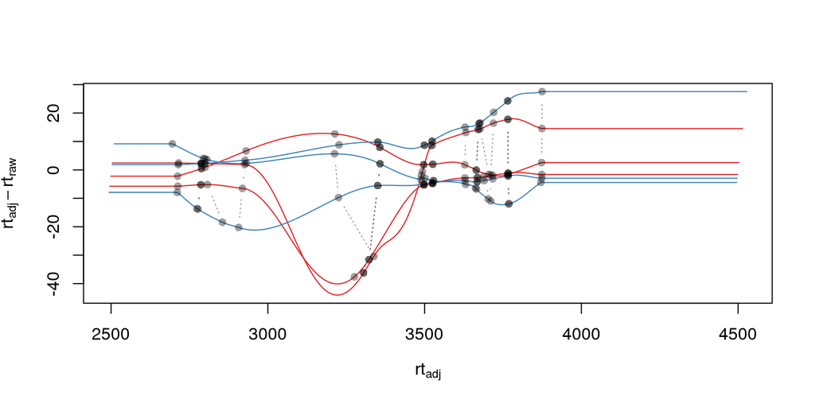

```r
plotAdjustedRtime(xod, col = sample_colors[pData(xod)$sample_group])
```

## 1.2 New naming convention

Methods for data analysis from the original `xcms` code have been renamed to avoid potential confusions:

- **Chromatographic peak detection**: `findChromPeaks` instead of `findPeaks`: for new functions and methods the term *peak* is avoided as much as possible, as it is usually used to describe a mass peak in mz dimension. To clearly distinguish between these peaks and peaks in retention time space, the latter are referred to as *chromatographic peak*, or `chromPeak`.
- **Correspondence**: `groupChromPeaks` instead of `group` to clearly indicate what is being grouped. Group might be a sample group or a peak group, the latter being referred to also by (mz-rt) *feature*.
- **Alignment**: `adjustRtime` instead of `retcor` for retention time correction. The word *cor* in *retcor* might be easily misinterpreted as *correlation* instead of correction.

## 1.3 New data classes

### 1.3.1 `OnDiskMSnExp`

This object is defined and documented in the `MSnbase` package. In brief, it is a container for the full raw data from an MS-based experiment. To keep the memory footprint low the mz and intensity values are only loaded from the raw data files when required. The `OnDiskMSnExp` object replaces the `xcmsRaw` object.

### 1.3.2 `XCMSnExp`

The `XCMSnExp` class extends the `OnDiskMSnExp` object from the `MSnbase` package and represents a container for the xcms-based preprocessing results while (since it inherits all functionality from its parent class) keeping a direct relation to the (raw) data on which the processing was performed. An additional slot `.processHistory` in the object allows to keep track of all performed processing steps. Each analysis method, such as `findChromPeaks` adds an `XProcessHistory` object which includes also the parameter class passed to the analysis method. Hence not only the time and type of the analysis, but its exact settings are reported within the `XCMSnExp` object. The `XCMSnExp` is thus equivalent to the `xcmsSet` from the original `xcms` implementation, but keeps in addition a link to the raw data on which the preprocessing was performed.

### 1.3.3 `Chromatogram`

The `Chromatogram` class allows a data representation that is orthogonal to the `Spectrum` class defined in `MSnbase`. The `Chromatogram` class stores retention time and intensity duplets and is designed to accommodate most use cases, from total ion chromatogram, base peak chromatogram to extracted ion chromatogram and SRM/MRM ion traces.

`Chromatogram` objects can be extracted from `XCMSnExp` objects using the `extractChromatograms` method.

Note that this class is still considered developmental and might thus undergo some changes in the future.

## 1.4 Binning and missing value imputation functions

The binning/profile matrix generation functions have been completely rewritten. The new `binYonX` function replaces the binning of intensity values into bins defined by their m/z values implemented in the `profBin`, `profBinLin` and `profBinLinBase` methods. The `binYonX` function provides also additional functionality:

- Breaks for the bins can be defined based on either the number of desired bins (`nBins`) or the size of a bin (`binSize`). In addition it is possible to provide a vector with pre-defined breaks. This allows to bin data from multiple files or scans on the same bin-definition.
- The function returns a list with element `y` containing the binned values and element `x` the bin mid-points.
- Values in input vector `y` can be aggregated within each bin with different methods: `max`, `min`, `sum` and `mean`.
- The index of the largest (or smallest for `method` being “min”) within each bin can be returned by setting argument `returnIndex` to `TRUE`.
- Binning can be performed on single or multiple sub-sets of the input vectors using the `fromIdx` and `toIdx` arguments. This replaces the *M* methods (such as `profBinM`). These sub-sets can be overlapping.

The missing value imputation logic inherently build into the `profBinLin` and `profBinLinBase` methods has been implemented in the `imputeLinInterpol` function.

The example below illustrates the binning and imputation with the `binYtoX` and `imputeLinInterpol` functions. After binning of the test vectors below some of the bins have missing values, for which we impute a value using `imputeLinInterpol`. By default, `binYonX` selects the largest value within each bin, but other aggregation methods are also available (i.e. min, max, mean, sum).

```r
## Defining the variables:
set.seed(123)
X <- sort(abs(rnorm(30, mean = 20, sd = 25))) ## 10
Y <- abs(rnorm(30, mean = 50, sd = 30))

## Bin the values in Y into 20 bins defined on X
res <- binYonX(X, Y, nBins = 22)

res
```

```
## $x
##  [1]  3.207154  6.066022  8.924891 11.783759 14.642628 17.501497 20.360365
##  [8] 23.219234 26.078102 28.936971 31.795840 34.654708 37.513577 40.372445
## [15] 43.231314 46.090183 48.949051 51.807920 54.666788 57.525657 60.384526
## [22] 63.243394
##
## $y
##  [1]  76.85377  76.34400  48.14265  29.15879  43.76248        NA 115.06868
##  [8]  86.23886        NA  73.39895  49.14360        NA  91.05807  43.22687
## [15]        NA        NA        NA  95.49412        NA        NA  67.53841
## [22]  56.47825
```

As a result we get a `list` with the bin mid-points (`$x`) and the binned `y` values (`$y`).

Next we use two different imputation approaches, a simple linear interpolation and the linear imputation approach that was defined in the `profBinLinBase` method. The latter performs linear interpolation only considering a certain neighborhood of missing values otherwise replacing the `NA` with a base value.

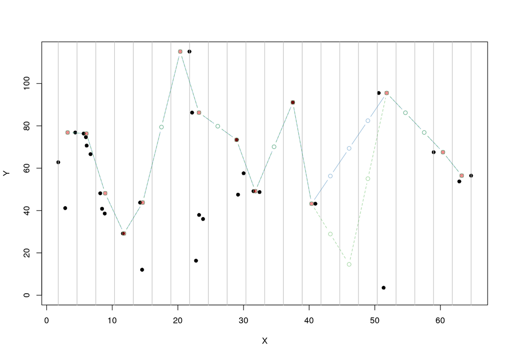

Figure 3: Binning and missing value imputation results. Black points represent the input values, red the results from the binning and blue and green the results from the imputation (with method lin and linbase, respectively).

```r
## Plot the actual data values.
plot(X, Y, pch = 16, ylim = c(0, max(Y)))
## Visualizing the bins
abline(v = breaks_on_nBins(min(X), max(X), nBins = 22), col = "grey")

## Define colors:
point_colors <- paste0(brewer.pal(4, "Set1"), 80)
## Plot the binned values.
points(x = res$x, y = res$y, col = point_colors[1], pch = 15)

## Perform the linear imputation.
res_lin <- imputeLinInterpol(res$y)

points(x = res$x, y = res_lin, col = point_colors[2], type = "b")

## Perform the linear imputation "linbase"
res_linbase <- imputeLinInterpol(res$y, method = "linbase")
points(x = res$x, y = res_linbase, col = point_colors[3], type = "b", lty = 2)
```

The difference between the linear interpolation method `lin` and `linbase` is that the latter only performs the linear interpolation in a pre-defined neighborhood of the bin with the missing value (`1` by default). The other missing values are set to a base value corresponding to half of the smallest bin value. Both methods thus yield same results, except for bins 15-17 (see Figure above).

## 1.5 Core functionality exposed *via* simple functions

- **peak detection methods**:
  - `do_findChromPeaks_centWave`: peak density and wavelet based peak detection for high resolution LC/MS data in centroid mode [@Tautenhahn:2008fx].
  - `do_findChromPeaks_matchedFilter`: identification of peak in the chromatographic domain based on matched filtration [@Smith:2006ic].
  - `do_findChromPeaks_massifquant`: identification of peaks using Kalman filters.
  - `do_findChromPeaks_MSW`: single spectrum, non-chromatographic peak detection.
- **alignment methods**:
  - `do_adjustRtime_peakGroups`: perform sample alignment (retention time correction) using alignment of *well behaved* chromatographic peaks that are present in most samples (and are expected to have the same retention time).
- **correspondence methods**:
  - `do_groupChromPeaks_density`: perform chromatographic peak grouping (within and across samples) based on the density distribution of peaks along the retention time axis.
  - `do_groupChromPeaks_nearest`: groups peaks across samples similar to the method implemented in mzMine.
  - `do_groupChromPeaks_mzClust`: performs high resolution correspondence on single spectra samples.

One possible drawback from the introduction of this new layer is, that more objects get copied by R which *could* eventually result in a larger memory demand or performance decrease (while no such was decrease was observed up to now).

## 1.6 Usability improvements in the *old* user interface

- `[` subsetting method for `xcmsRaw` objects that enables to subset an `xcmsRaw` object to specific scans/spectra.
- `profMat` method to extract the *profile* matrix from the `xcmsRaw` object. This method should be used instead of directly accessing the `@env$profile` slot, as it will create the profile matrix on the fly if it was not pre-calculated (or if profile matrix generation settings have been changed).

# 2 Changes due to bug fixes and modified functionality

## 2.1 Differences in linear interpolation of missing values (`profBinLin`).

From `xcms` version 1.51.1 on the new binning functions are used, thus, the bug described here are fixed.

Two bugs are present in the `profBinLin` method (reported as issues [#46](https://github.com/sneumann/xcms/issues/46) and [#49](https://github.com/sneumann/xcms/issues/49) on github) which are fixed in the new `binYonX` and `imputeLinInterpol` functions:

- The first bin value calculated by `profBinLin` can be wrong (i.e. not being the max value within that bin, but the first).
- If the last bin contains also missing values, the method fails to determine a correct value for that bin.

The `profBinLin` method is used in `findPeaks.matchedFilter` if the profile method is set to “binlin”.

The example below illustrates both differences.

```r
## Define a vector with empty values at the end.
X <- 1:11
set.seed(123)
Y <- sort(rnorm(11, mean = 20, sd = 10))
Y[9:11] <- NA
nas <- is.na(Y)
## Do interpolation with profBinLin:
resX <- xcms:::profBinLin(X[!nas], Y[!nas], 5, xstart = min(X),
              xend = max(X))
resX
```

```
## [1]  7.349388 15.543380 21.292877  0.000000  0.000000
```

```r
res <- binYonX(X, Y, nBins = 5L, shiftByHalfBinSize = TRUE)
resM <- imputeLinInterpol(res$y, method = "lin",
              noInterpolAtEnds = TRUE)
resM
```

```
## [1] 13.13147 15.54338 21.29288 24.60916  0.00000
```

Plotting the results helps to better compare the differences. The black points in the figure below represent the actual values of `Y` and the grey vertical lines the breaks defining the bins. The blue lines and points represent the result from the `profBinLin` method. The bin values for the first and 4th bin are clearly wrong. The green colored points and lines represent the results from the `binYonX` and `imputeLinInterpol` functions (showing the correct binning and interpolation).

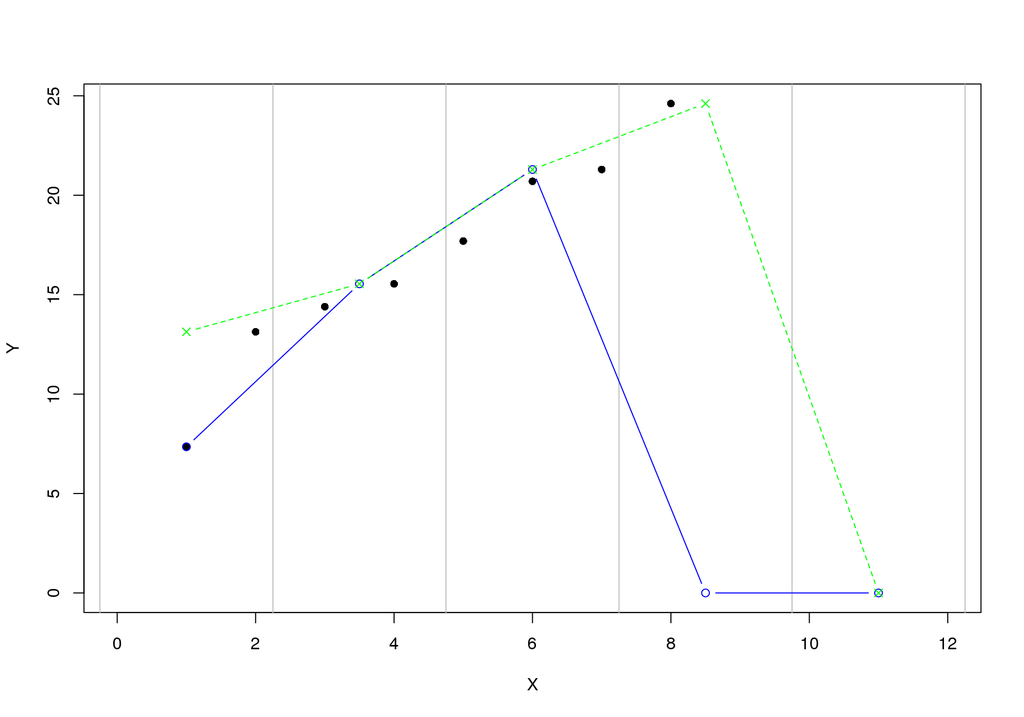

Figure 4: Illustration of the two bugs in profBinLin. The input values are represented by black points, grey vertical lines indicate the bins. The results from binning and interpolation with profBinLin are shown in blue and those from binYonX in combination with imputeLinInterpol in green.

```r
plot(x = X, y = Y, pch = 16, ylim = c(0, max(Y, na.rm = TRUE)),
     xlim = c(0, 12))
## Plot the breaks
abline(v = breaks_on_nBins(min(X), max(X), 5L, TRUE), col = "grey")
## Result from profBinLin:
points(x = res$x, y = resX, col = "blue", type = "b")
## Results from imputeLinInterpol
points(x = res$x, y = resM, col = "green", type = "b",
       pch = 4, lty = 2)
```

Note that by default `imputeLinInterpol` would also interpolate missing values at the beginning and the end of the provided numeric vector. This can be disabled (to be compliant with `profBinLin`) by setting parameter `noInterpolAtEnds` to `TRUE` (like in the example above).

## 2.2 Differences due to updates in `do_findChromPeaks_matchedFilter`, respectively `findPeaks.matchedFilter`.

The original `findPeaks.matchedFilter` (up to version 1.49.7) had several shortcomings and bugs that have been fixed in the new `do_findChromPeaks_matchedFilter` method:

- The internal iterative processing of smaller chunks of the full data (also referred to as *iterative buffering*) could result, for some bin (step) sizes to unstable binning results (discussed in issue [#47](https://github.com/sneumann/xcms/issues/47) on github): calculation of the breaks, or to be precise, the actually used bin size was performed in each iteration and could lead to slightly different sizes between iterations (due to rounding errors caused by floating point number representations in C).
- The iterative buffering raises also a conceptual issue when linear interpolation is performed to impute missing values: the linear imputation will only consider values within the actually processed buffer and can thus lead to wrong or inaccurate imputations.
- The `profBinLin` implementation contains two bugs, one that can result in failing to identify the maximal value in the first and last bin (see issue [#46](https://github.com/sneumann/xcms/issues/46)) and one that fails to assign a value to a bin (issue [#49](https://github.com/sneumann/xcms/issues/49)). Both are fixed in the `do_findChromPeaks_matchedFilter` implementation.

A detailed description of tests comparing all implementations is available in issue [#52](https://github.com/sneumann/xcms/issues/52) on github. Note also that in course of these changes also the `getEIC` method has been updated to use the new binning and missing value imputation function.

While it is strongly discouraged, it is still possible to use to *old* code (from 1.49.7) by calling `useOriginalCode(TRUE)`.

## 2.3 Differences in `findPeaks.massifquant`

- Argument `scanrange` was ignored in the *original* old code (issue [#61](https://github.com/sneumann/xcms/issues/61)).
- The method returned a `matrix` if `withWave` was `0` and a `xcmsPeaks` object otherwise. The updated version returns **always** an `xcmsPeaks` object (issue #60).

## 2.4 Differences in *obiwarp* retention time correction

Retention time correction using the obiwarp method uses the *profile* matrix (i.e. intensities binned in discrete bins along the mz axis). Profile matrix generation uses now the `binYonX` method which fixed some problems in the original binning and linear interpolation methods. Thus results might be slightly different.

Also, the `retcor.obiwarp` method reports (un-rounded) adjusted retention times, but adjusts the retention time of eventually already identified peaks using rounded adjusted retention times. The new `adjustRtime` method(s) does adjust identified peaks using the reported adjusted retention times (not rounded). This guarantees that e.g. removing retention time adjustment/alignment results from an object restores the object to its initial state (i.e. the adjusted retention times of the identified peaks are reverted to the retention times before alignment). See issue [#122](https://github.com/sneumann/xcms/issues/122) for more details.

## 2.5 `retcor.peaksgroups`: change in the way how *well behaved* peak groups are ordered

The `retcor.peakgroups` defines first the chromatographic peak groups that are used for the alignment of all spectra. Once these are identified, the retention time of the peak with the highest intensity in a sample for a given peak group is returned and the peak groups are ordered increasingly by retention time (which is required for the later fitting of either a polynomial or a linear model to the data). The selection of the retention time of the peak with the highest intensity within a feature (peak group) and samples, denoted as *representative* peak for a given feature in a sample, ensures that only the retention time of a single peak per sample and feature is selected (note that multiple chromatographic peaks within the same sample can be assigned to a feature). In the original code the ordering of the peak groups was however performed using the median retention time of the complete peak group (which includes also potential additional peaks per sample). This has been changed and the features are ordered now by the median retention time across samples of the representative chromatographic peaks.

## 2.6 `scanrange` parameter in all `findPeaks` methods

The `scanrange` in the `findPeaks` methods is supposed to enable the peak detection only within a user-defined range of scans. This was however not performed in each method. Due to a bug in `findPeaks.matchedFilter`’s original code the argument was ignored, except if the upper scan number of the user defined range was larger than the total number of available scans (see issue [#63](https://github.com/sneumann/xcms/issues/63)). In `findPeaks.massifquant` the argument was completely ignored (see issue [#61](https://github.com/sneumann/xcms/issues/61)) and, while the argument was considered in `findPeaks.centWave` and feature detection was performed within the specified scan range, but the original `@scantime` slot was used throughout the code instead of just the scan times for the specified scan indices (see issue [#64](https://github.com/sneumann/xcms/issues/64)).

These problems have been fixed in version 1.51.1 by first sub-setting the `xcmsRaw` object (using the `[` method) before actually performing the feature detection.

## 2.7 `fillPeaks` (`fillChromPeaks`) differences

In the original `fillPeaks.MSW`, the mz range from which the signal is to be integrated was defined using

```r
mzarea <- seq(which.min(abs(mzs - peakArea[i, "mzmin"])),
          which.min(abs(mzs - peakArea[i, "mzmax"])))
```

Depending on the data this could lead to the inclusion of signal in the integration that are just outside of the mz range. In the new `fillChromPeaks` method signal is integrated only for mz values >= mzmin and <= mzmax thus ensuring that only signal is used that is truly within the peak area defined by columns `"mzmin"`, `"mzmax"`, `"rtmin"` and `"rtmax"`.

Also, the `fillPeaks.chrom` method did return `"into"` and `"maxo"` values of `0` if no signal was found in the peak area. The new method does not integrate any signal in such cases and does not fill in that peak.

See also issue [#130](https://github.com/sneumann/xcms/issues/130) for more information.

# 3 Under the hood changes

These changes and updates will not have any large impact on the day-to-day use of `xcms` and are listed here for completeness.

- From `xcms` version 1.51.1 on the default methods from the `mzR` package are used for data import. Besides ensuring easier maintenance, this enables also data import from *gzipped* mzML files.

# 4 Deprecated functions and files

Here we list all of the functions and related files that are deprecated.

- `xcmsParallelSetup`, `xcmsPapply`, `xcmsClusterApply`: use `BiocParallel` package instead to setup and perform parallel processing, either *via* the `BPPARAM` parameter to function and methods, or by calling `register` to globally set parallel processing.
- `profBin`, `profBinM`, `profBinLin`, `profBinLinM`, `profBinLinBase`, `profBinLinBaseM`: replaced by the `binYonX` and `imputeLinInterpol` functions. Also, to create or extract the profile matrix from an `xcmsRaw` object, the `profMat` method.

## 4.1 Deprecated

### 4.1.1 xcms 1.49:

- `xcmsParallelSetup` (Deprecated.R)
- `xcmsPapply` (Deprecated.R)
- `xcmsClusterApply` (Deprecated.R)

### 4.1.2 xcms 1.51:

- `profBin` (c.R)
- `profBinM` (c.R)
- `profBinLin` (c.R)
- `profBinLinM` (c.R)
- `profBinLinBase` (c.R)
- `profBinLinBaseM` (c.R)

## 4.2 Defunct

# 5 References